# HW2_6337_MXB220061_HXD220000_2023

2023-02-20

Authors : Mankirat Singh Bharma MXB220061 - Harikrishna Dev HXD220000

Loading required libraries and cleaning environment

```r
rm(list = ls())
demo = T
require(psych)
require(data.table)
require(dplyr)
```

```r
require(ggplot2)
if(demo) {setwd("~/Library/Mobile Documents/com~apple~CloudDocs/School Work/Sem 2/BUAN 6337/HW/pset2")}
```

Section - 1

1. The United States Geological Survey provides data on earthquakes of historical interest. Earthquakes.csv contains data about earthquakes with a magnitude greater than 2.5 in the United States and its territories. The variables are year, month, day, state, and magnitude.
1. California and Alaska are the two states with the highest number of earthquakes in the country. Read the data and create a new data set that includes only these two by filtering only the relevant rows.

```r
ertqks <- fread("earthquakes.csv",header = T)[State %in%  c("Alaska","California"),]
if(demo) {str(ertqks)
summary(ertqks)
}
```

```
## Classes 'data.table' and 'data.frame':   169 obs. of  5 variables:
##  $ Year     : int  1964 1965 1957 1938 1946 1899 2002 1996 1986 1899 ...
##  $ Month    : int  3 2 3 11 4 9 11 6 5 9 ...
##  $ Day      : int  28 4 9 10 1 10 3 10 7 4 ...
##  $ State    : chr  "Alaska" "Alaska" "Alaska" "Alaska" ...
##  $ Magnitude: num  9.2 8.7 8.6 8.2 8.1 8 7.9 7.9 7.9 7.9 ...
##  - attr(*, ".internal.selfref")=<externalptr>
```

```
##       Year          Month             Day           State
##  Min.   :1812   Min.   : 1.000   Min.   : 1.00   Length:169
##  1st Qu.:1933   1st Qu.: 4.000   1st Qu.: 8.00   Class :character
##  Median :1984   Median : 6.000   Median :17.00   Mode  :character
##  Mean   :1965   Mean   : 6.343   Mean   :16.42
##  3rd Qu.:2003   3rd Qu.: 9.000   3rd Qu.:24.00
##  Max.   :2010   Max.   :12.000   Max.   :31.00
##                                  NA's   :1
##    Magnitude
##  Min.   :3.000
##  1st Qu.:5.400
##  Median :6.500
##  Mean   :6.228
##  3rd Qu.:7.100
##  Max.   :9.200
##
```

2. You are interested in the following statistics for the magnitude of earthquake:- Mean-Median-Standard Deviation-Minimum and maximum-25thand 75thpercentiles Create a table that shows the above statistics across different states within each year. In particular, your table must have years at the first column and it must break down the results across different states in the second column. In order to make the table short, further assume you are interested only in recent years and want to create a table that shows the desired statistics from 2002 to 2011

```r
summary_ertqks <- ertqks[,':='(mean=mean(Magnitude), median = median(Magnitude),std = sd(Magnitude),min = min(Magnitude),max=max(Magnitude),percentile.25 = quantile(Magnitude,0.25),percentile.75 = quantile(Magnitude,0.75)),by=c("Year","State")]

if(demo) {summary(summary_ertqks)}
```

```
##       Year          Month             Day           State
##  Min.   :1812   Min.   : 1.000   Min.   : 1.00   Length:169
##  1st Qu.:1933   1st Qu.: 4.000   1st Qu.: 8.00   Class :character
##  Median :1984   Median : 6.000   Median :17.00   Mode  :character
##  Mean   :1965   Mean   : 6.343   Mean   :16.42
##  3rd Qu.:2003   3rd Qu.: 9.000   3rd Qu.:24.00
##  Max.   :2010   Max.   :12.000   Max.   :31.00
##                                  NA's   :1
##    Magnitude          mean           median           std
##  Min.   :3.000   Min.   :4.000   Min.   :3.900   Min.   :0.0000
##  1st Qu.:5.400   1st Qu.:5.450   1st Qu.:5.050   1st Qu.:0.4950
##  Median :6.500   Median :6.500   Median :6.500   Median :0.6229
##  Mean   :6.228   Mean   :6.228   Mean   :6.163   Mean   :0.6623
##  3rd Qu.:7.100   3rd Qu.:7.100   3rd Qu.:7.000   3rd Qu.:0.8758
##  Max.   :9.200   Max.   :9.200   Max.   :9.200   Max.   :2.1213
##                                                  NA's   :60
##       min             max       percentile.25  percentile.75
##  Min.   :3.000   Min.   :4.50   Min.   :3.50   Min.   :4.450
##  1st Qu.:5.000   1st Qu.:6.40   1st Qu.:5.00   1st Qu.:5.800
##  Median :6.200   Median :7.00   Median :6.40   Median :6.600
##  Mean   :5.841   Mean   :6.82   Mean   :5.99   Mean   :6.412
##  3rd Qu.:7.000   3rd Qu.:7.30   3rd Qu.:7.00   3rd Qu.:7.100
##  Max.   :9.200   Max.   :9.20   Max.   :9.20   Max.   :9.200
##
```

```r
summary_ertqks_flt <- summary_ertqks[Year>=2002 & Year<=2011,]
summary_ertqks_flt <- summary_ertqks_flt[order(Year,State)]

if(demo) {str(summary_ertqks_flt)
  summary(summary_ertqks_flt)}
```

```
## Classes 'data.table' and 'data.frame':   61 obs. of  12 variables:
##  $ Year         : int  2002 2002 2002 2002 2002 2002 2002 2002 2002 2003 ...
##  $ Month        : int  11 10 2 6 5 9 3 11 12 11 ...
##  $ Day          : int  3 23 6 17 14 3 16 24 24 17 ...
##  $ State        : chr  "Alaska" "Alaska" "Alaska" "California" ...
##  $ Magnitude    : num  7.9 6.7 5.3 5.3 4.9 4.8 4.6 3.9 3.6 7.8 ...
##  $ mean         : num  6.63 6.63 6.63 4.52 4.52 ...
##  $ median       : num  6.7 6.7 6.7 4.7 4.7 4.7 4.7 4.7 4.7 7 ...
##  $ std          : num  1.301 1.301 1.301 0.643 0.643 ...
##  $ min          : num  5.3 5.3 5.3 3.6 3.6 3.6 3.6 3.6 3.6 6.6 ...
##  $ max          : num  7.9 7.9 7.9 5.3 5.3 5.3 5.3 5.3 5.3 7.8 ...
##  $ percentile.25: num  6 6 6 4.08 4.08 ...
##  $ percentile.75: num  7.3 7.3 7.3 4.88 4.88 ...
##  - attr(*, ".internal.selfref")=<externalptr>
```

```
##       Year          Month             Day           State
##  Min.   :2002   Min.   : 1.000   Min.   : 2.00   Length:61
##  1st Qu.:2003   1st Qu.: 4.000   1st Qu.:10.00   Class :character
##  Median :2004   Median : 6.000   Median :17.00   Mode  :character
##  Mean   :2005   Mean   : 6.344   Mean   :17.33
##  3rd Qu.:2007   3rd Qu.: 9.000   3rd Qu.:24.00
##  Max.   :2010   Max.   :12.000   Max.   :31.00
##
##    Magnitude          mean           median           std
##  Min.   :3.000   Min.   :4.000   Min.   :3.900   Min.   :0.0000
##  1st Qu.:4.100   1st Qu.:4.287   1st Qu.:4.000   1st Qu.:0.5621
##  Median :4.900   Median :4.740   Median :4.700   Median :0.6432
##  Mean   :5.167   Mean   :5.167   Mean   :5.028   Mean   :0.7709
##  3rd Qu.:6.500   3rd Qu.:6.500   3rd Qu.:6.500   3rd Qu.:0.8758
##  Max.   :7.900   Max.   :7.100   Max.   :7.000   Max.   :2.1213
##                                                  NA's   :6
##       min             max        percentile.25   percentile.75
##  Min.   :3.000   Min.   :4.500   Min.   :3.500   Min.   :4.45
##  1st Qu.:3.400   1st Qu.:5.500   1st Qu.:3.700   1st Qu.:4.65
##  Median :4.100   Median :6.600   Median :4.300   Median :5.20
##  Mean   :4.464   Mean   :6.316   Mean   :4.736   Mean   :5.53
##  3rd Qu.:5.400   3rd Qu.:7.200   3rd Qu.:6.000   3rd Qu.:6.50
##  Max.   :6.800   Max.   :7.900   Max.   :6.825   Max.   :7.30
##
```

3. Modify your R code in (b) such that the results for each year is shown in a separate table.

```r
year <- unique(summary_ertqks_flt$Year)

for(i in year) {
  assign(paste0("ertqk",i),as.data.table(summary_ertqks_flt[Year ==i,]))
  str(get(paste0("ertqk",i)))
}
```

```
## Classes 'data.table' and 'data.frame':   9 obs. of  12 variables:
##  $ Year         : int  2002 2002 2002 2002 2002 2002 2002 2002 2002
##  $ Month        : int  11 10 2 6 5 9 3 11 12
##  $ Day          : int  3 23 6 17 14 3 16 24 24
##  $ State        : chr  "Alaska" "Alaska" "Alaska" "California" ...
##  $ Magnitude    : num  7.9 6.7 5.3 5.3 4.9 4.8 4.6 3.9 3.6
##  $ mean         : num  6.63 6.63 6.63 4.52 4.52 ...
##  $ median       : num  6.7 6.7 6.7 4.7 4.7 4.7 4.7 4.7 4.7
##  $ std          : num  1.301 1.301 1.301 0.643 0.643 ...
##  $ min          : num  5.3 5.3 5.3 3.6 3.6 3.6 3.6 3.6 3.6
##  $ max          : num  7.9 7.9 7.9 5.3 5.3 5.3 5.3 5.3 5.3
##  $ percentile.25: num  6 6 6 4.08 4.08 ...
##  $ percentile.75: num  7.3 7.3 7.3 4.88 4.88 ...
##  - attr(*, ".internal.selfref")=<externalptr>
## Classes 'data.table' and 'data.frame':   19 obs. of  12 variables:
```

[output cut: 111 more lines]

4. Now, assume you want to show the same results in part (b)but with the difference that years are shown is the first column and the states are shown in the top row.

```r
ertqk_summary <- dcast(summary_ertqks_flt,Year ~ State,fun = mean,value.var = c("mean", "median", "std", "min", "max","percentile.25","percentile.75"))
if(demo) {str(ertqk_summary)}
```

```
## Classes 'data.table' and 'data.frame':   9 obs. of  15 variables:
##  $ Year                    : int  2002 2003 2004 2005 2006 2007 2008 2009 2010
##  $ mean_Alaska             : num  6.63 7.1 6.8 6.8 4.8 ...
##  $ mean_California         : num  4.52 4.29 4.5 5.45 4.5 ...
##  $ median_Alaska           : num  6.7 7 6.8 6.8 4.8 6.6 6.6 5.8 NaN
##  $ median_California       : num  4.7 4 4.5 5.05 4.5 4.4 5.45 3.9 6.5
##  $ std_Alaska              : num  1.3 0.51 NA NA NA ...
##  $ std_California          : num  0.643 0.876 2.121 1.195 NA ...
##  $ min_Alaska              : num  5.3 6.6 6.8 6.8 4.8 6.4 6.6 5.8 NaN
##  $ min_California          : num  3.6 3.4 3 4.1 4.5 4.2 5.4 3.5 6.5
##  $ max_Alaska              : num  7.9 7.8 6.8 6.8 4.8 7.2 6.6 5.8 NaN
##  $ max_California          : num  5.3 6.6 6 7.2 4.5 5.6 5.5 4.7 6.5
##  $ percentile.25_Alaska    : num  6 6.83 6.8 6.8 4.8 ...
##  $ percentile.25_California: num  4.08 3.7 3.75 4.75 4.5 ...
##  $ percentile.75_Alaska    : num  7.3 7.28 6.8 6.8 4.8 ...
##  $ percentile.75_California: num  4.88 4.65 5.25 6.25 4.5 ...
##  - attr(*, ".internal.selfref")=<externalptr>
##  - attr(*, "sorted")= chr "Year"
```

5. You are interested in how the magnitude of earthquakes is trending over time for each state. In one graph, plot two time series plots, side by side,which shows the trend of average magnitude of earthquakes over time for the two states

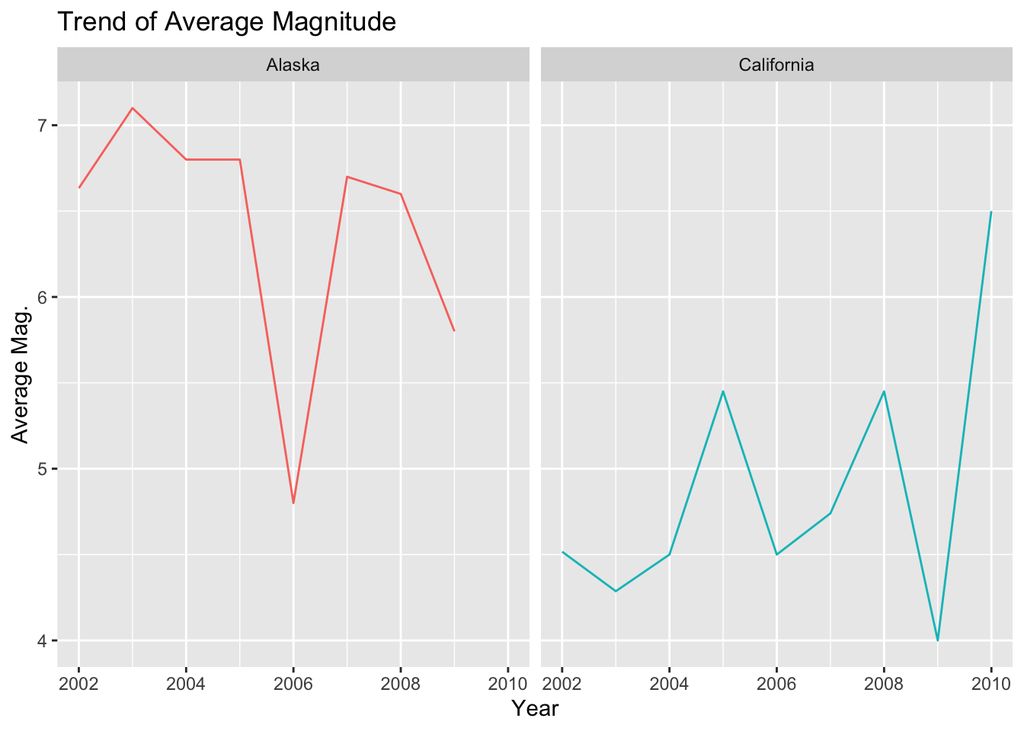

```r
summary_ertqks_flt %>%
ggplot(aes(Year,mean))+
geom_line(aes(colour = summary_ertqks_flt$State))+ labs(x = "Year" , y ="Average Mag." )+ facet_wrap(~summary_ertqks_flt$State, nrow = 1)+ theme(legend.position = "none")+
ggtitle("Trend of Average Magnitude")
```

6. Test the following null hypothesis: “the average magnitude of earthquakes in California is equal to that of Alaska”

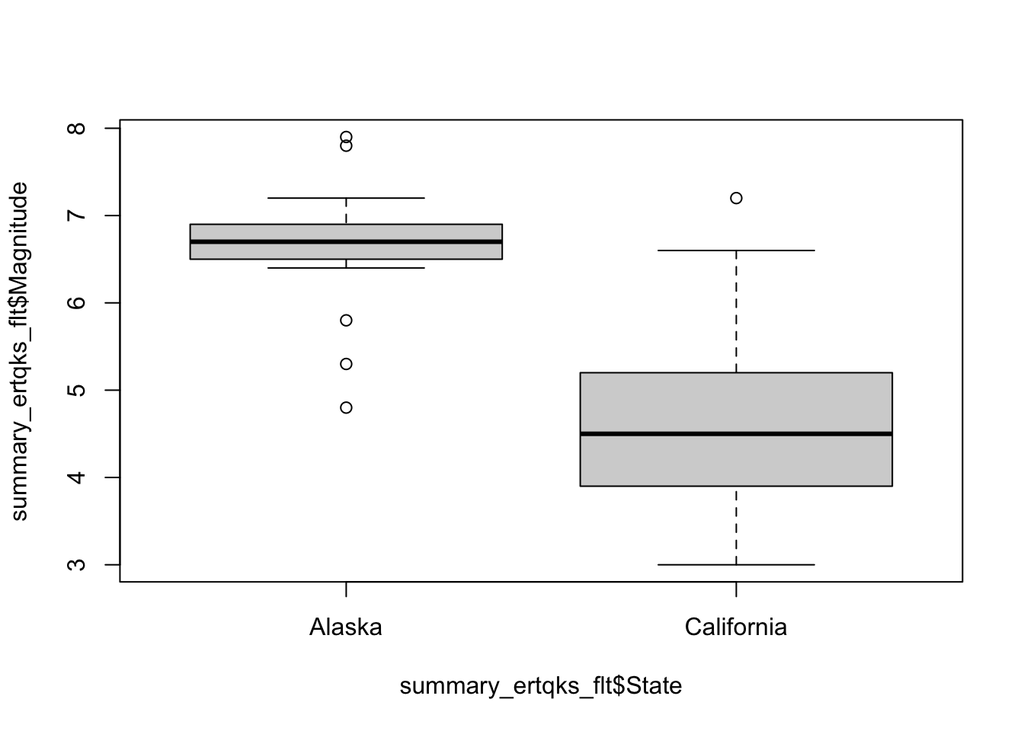

```r
boxplot(summary_ertqks_flt$Magnitude ~ summary_ertqks_flt$State)
```

H0: Avg Magnitude (California) = Avg Magnitude (Alaska)

H1: Avg Magnitude (California) <> Avg Magnitude (Alaska)

```r
t.test(summary_ertqks_flt$Magnitude ~ summary_ertqks_flt$State)
```

```
##
##  Welch Two Sample t-test
##
## data:  summary_ertqks_flt$Magnitude by summary_ertqks_flt$State
## t = 8.4493, df = 36.554, p-value = 4.043e-10
## alternative hypothesis: true difference in means between group Alaska and group California is not equal to 0
## 95 percent confidence interval:
##  1.528420 2.493237
## sample estimates:
##     mean in group Alaska mean in group California
##                 6.617647                 4.606818
```

Since p- value was less than 0.05, we reject the null hypothesis

Q. 2 Suppose that at a local university the study guidelines for the College of Science and Math are to study two to three hours per unit per week. The instructor of the class, Orientation to the Statistics Major, takes these guidelines very seriously. He asks students to record their study time each week, and at the end of the term he compares their average study time per week to their term GPA. “study_gpa.csv” contains student identification information, orientation course-section number, number of units enrolled, average time studied, and term GPA.

1. Graph the histogram for hours of study. Use the startpoint=0 and bandwidth=5.Also, overlaid to this graph, display the plots for the kernel density and the best fitting normal curve. Using an eyeballing approach, can we say the hours of study follows a normal distribution?(Hint: usegeom_histogram() and geom_density() in ggplot2)

```r
gpa <- fread("study_gpa.csv",header = T)

if(demo) {str(gpa)}
```

```
## Classes 'data.table' and 'data.frame':   122 obs. of  7 variables:
##  $ ID      : int  1005 1026 1045 1063 1071 1082 1096 1108 1120 1181 ...
##  $ FInitial: chr  "J" "E" "R" "T" ...
##  $ LastName: chr  "Bryant" "Fisher" "Turner" "Howard" ...
##  $ Section : int  2 2 2 1 1 2 2 2 2 2 ...
##  $ Units   : int  10 18 19 9 14 12 19 11 16 12 ...
##  $ AveTime : num  21.4 10.4 48.4 18.3 49.7 ...
##  $ GPA     : num  1.93 2.19 2.23 3.3 2.42 2.42 2.45 2.48 2.5 2.5 ...
##  - attr(*, ".internal.selfref")=<externalptr>
```

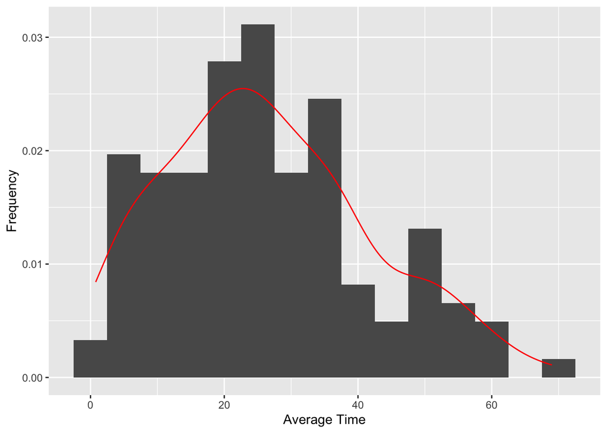

```r
hist_plot <- ggplot(gpa, aes(AveTime)) +
geom_histogram(aes(y=..density..), binwidth = 5) + # scale histogram y
geom_density(col = "red")
print(hist_plot + labs(x="Average Time",y = "Frequency"))
```

Upon looking at the histogram, we can conclude that the distribution is positively(right) skewed distribution.

2. Check statistics of the average hours of study.

```r
summary(gpa$AveTime)
```

```
##    Min. 1st Qu.  Median    Mean 3rd Qu.    Max.
##  0.7729 15.1945 24.8211 26.3651 36.5434 69.0068
```

3. Conduct a hypothesis test to check whether there exists a significance correlation between units enrolled, hours of study and GPA for section 2. What is your conclusion? Doe correlation mean that one variable causes the other?

```r
# H0: GPA

var = names(gpa)[5:7]

forms <- lapply(1:length(var),function(i) formula(paste(var[i], "~", paste(var[-i], collapse = "+"))))

models <- lapply(forms,aov,data = gpa[Section == 2])

for(i in 1:length(forms)) {
  print(paste("Model:",forms[i]))
  print(summary(models[[i]]))
  }
```

```
## [1] "Model: Units ~ AveTime + GPA"
##             Df Sum Sq Mean Sq F value  Pr(>F)
## AveTime      1   71.0   71.03   8.261 0.00557 **
## GPA          1    1.5    1.49   0.173 0.67914
## Residuals   61  524.5    8.60
## ---
## Signif. codes:  0 '***' 0.001 '**' 0.01 '*' 0.05 '.' 0.1 ' ' 1
## [1] "Model: AveTime ~ Units + GPA"
##             Df Sum Sq Mean Sq F value  Pr(>F)
## Units        1   1752  1751.7   8.361 0.00531 **
## GPA          1    191   190.8   0.911 0.34365
## Residuals   61  12781   209.5
## ---
## Signif. codes:  0 '***' 0.001 '**' 0.01 '*' 0.05 '.' 0.1 ' ' 1
## [1] "Model: GPA ~ Units + AveTime"
##             Df Sum Sq Mean Sq F value Pr(>F)
## Units        1  0.002 0.00174   0.008  0.927
## AveTime      1  0.187 0.18718   0.911  0.344
## Residuals   61 12.535 0.20549
```

Q.3 A study was conducted to see whether taking vitamin E daily would reduce the levels of atherosclerotic disease in a random sample of 500 individuals. Clinical measurements, including thickness of plaque of the carotid artery (taken via ultrasound), were recorded at baseline and at two subsequent visits in a data set “vite.csv”. Patients were divided into two strata according to their baseline plaque measurement.

1. First,read the data.The variable descriptions are as follows:

ID: individual identifier

Strata: 1=baseline plaque above 0.60mm+, 2=baseline plaque below 0.60mm Treatment: 0=placebo group, 1=vitamin E treatment

Plaque: Plaque measurement (mm)

HDL: HDL cholesterol (mg/DL)

LDL: LDL cholesterol (mg/DL)

Visit: 0=baseline, 1=first year, 2=second year

Trig: Triglycerides mg/DL

SBP: Systolic blood pressure (mm/Mg)

DBP: Diastolic blood pressure (mm/Mg)

Alcohol: # alcoholic drinks per day

Smoke: # cigarettes smoked per day

```r
vite <- fread("vite.csv",header = T,na.strings = c("NA",""),sep = "auto",stringsAsFactors = F)

if(demo) {str(vite)
  summary(vite)}
```

```
## Classes 'data.table' and 'data.frame':   1500 obs. of  12 variables:
##  $ ID       : int  1 1 1 2 2 2 3 3 3 4 ...
##  $ Visit    : int  0 1 2 0 1 2 0 1 2 0 ...
##  $ Strata   : int  1 1 1 1 1 1 1 1 1 1 ...
##  $ Treatment: int  0 0 0 0 0 0 0 0 0 0 ...
##  $ Plaque   : num  0.807 0.758 0.81 0.758 0.687 ...
##  $ HDL      : int  42 44 40 39 46 53 53 36 39 46 ...
##  $ LDL      : int  127 143 158 138 147 161 133 146 119 139 ...
##  $ Trig     : int  149 49 98 211 29 177 163 198 140 247 ...
##  $ SBP      : int  106 131 136 157 154 65 169 172 140 142 ...
##  $ DBP      : int  70 109 87 100 108 70 106 91 90 103 ...
##  $ Alcohol  : int  1 2 2 1 2 3 1 2 3 0 ...
##  $ Smoke    : int  0 0 0 6 6 6 0 0 0 0 ...
##  - attr(*, ".internal.selfref")=<externalptr>
```

```
##        ID            Visit       Strata      Treatment       Plaque
##  Min.   :  1.0   Min.   :0   Min.   :1.0   Min.   :0.0   Min.   :0.2209
##  1st Qu.:125.8   1st Qu.:0   1st Qu.:1.0   1st Qu.:0.0   1st Qu.:0.4812
##  Median :250.5   Median :1   Median :1.5   Median :0.5   Median :0.5998
##  Mean   :250.5   Mean   :1   Mean   :1.5   Mean   :0.5   Mean   :0.6329
##  3rd Qu.:375.2   3rd Qu.:2   3rd Qu.:2.0   3rd Qu.:1.0   3rd Qu.:0.7830
##  Max.   :500.0   Max.   :2   Max.   :2.0   Max.   :1.0   Max.   :1.0808
##       HDL             LDL             Trig            SBP
##  Min.   :22.00   Min.   : 83.0   Min.   : 25.0   Min.   : 65.0
##  1st Qu.:41.00   1st Qu.:126.0   1st Qu.:106.0   1st Qu.:123.0
##  Median :46.00   Median :136.0   Median :167.0   Median :142.0
##  Mean   :45.87   Mean   :135.5   Mean   :173.6   Mean   :141.9
##  3rd Qu.:50.00   3rd Qu.:145.0   3rd Qu.:229.0   3rd Qu.:161.2
##  Max.   :71.00   Max.   :185.0   Max.   :503.0   Max.   :234.0
##       DBP            Alcohol           Smoke
##  Min.   : 38.00   Min.   :0.0000   Min.   : 0.000
##  1st Qu.: 84.00   1st Qu.:0.0000   1st Qu.: 0.000
##  Median : 92.00   Median :0.0000   Median : 0.000
##  Mean   : 92.03   Mean   :0.7287   Mean   : 3.523
##  3rd Qu.:101.00   3rd Qu.:1.0000   3rd Qu.: 5.000
##  Max.   :138.00   Max.   :7.0000   Max.   :34.000
```

2. Note that the current data is in long format. We first want to transform the data to wide format so that we can conduct certain statistical analyses. Basically, long formats have repeated observations for a given person, whereas wide formats record those observations column-wise. Create the data so that plague values for each visit (0, 1, 2) are recorded in 3 separate columns as opposed to 3 rows, by ID and treatment. (cf. Reference: https://data.library.virginia.edu/reshaping-data-from-wide-to-long/ although you may want to stick with the data.table() syntax and commands)

```r
vite_fnl <- dcast(vite,formula = ID+Treatment~Visit,value.var = "Plaque")

colNames <- c("baseline","first_year","second_year")
colnames(vite_fnl)[3:5] <- colNames

##vite_0 <- vite_fnl[vite_fnl$Treatment == 0]

if(demo) {str(vite_fnl)}
```

```
## Classes 'data.table' and 'data.frame':   500 obs. of  5 variables:
##  $ ID         : int  1 2 3 4 5 6 7 8 9 10 ...
##  $ Treatment  : int  0 0 0 0 0 0 0 0 0 0 ...
##  $ baseline   : num  0.807 0.758 0.752 0.816 0.798 ...
##  $ first_year : num  0.758 0.687 0.786 0.6 0.957 ...
##  $ second_year: num  0.81 0.823 0.803 0.969 0.797 ...
##  - attr(*, ".internal.selfref")=<externalptr>
##  - attr(*, "sorted")= chr [1:2] "ID" "Treatment"
```

3. Assume there were no placebo group (i.e., treatment = 0) in your data set. Conduct a test to see whether there is a difference in plaque level before treatment and after the second visit? Interpret your results.

H0: Baseline = Second year H1: Baseline <> Second year

```r
t.test(vite_fnl$baseline[vite_fnl$Treatment == 1],vite_fnl$second_year[vite_fnl$Treatment == 1],paired = T)
```

```
##
##  Paired t-test
##
## data:  vite_fnl$baseline[vite_fnl$Treatment == 1] and vite_fnl$second_year[vite_fnl$Treatment == 1]
## t = 3.9816, df = 249, p-value = 8.987e-05
## alternative hypothesis: true mean difference is not equal to 0
## 95 percent confidence interval:
##  0.01504613 0.04450187
## sample estimates:
## mean difference
##        0.029774
```

As p_value < 0.05, we can rejected the null hypothesis.

4. Now, considering the fact that there is indeed a control group in your dataset, conduct a new test to check whether there is a difference in plaque level before treatment and after the second visit. Interpret your results

H0: treatment hasn’t effected the levels of plaque H1: treatment has effected the levels of plaque

```r
vite_fnl$diff <-vite_fnl$second_year - vite_fnl$baseline
t.test(vite_fnl$diff[vite_fnl$Treatment == 1],vite_fnl$diff[vite_fnl$Treatment == 0], paired = T)
```

```
##
##  Paired t-test
##
## data:  vite_fnl$diff[vite_fnl$Treatment == 1] and vite_fnl$diff[vite_fnl$Treatment == 0]
## t = -1.6986, df = 249, p-value = 0.09065
## alternative hypothesis: true mean difference is not equal to 0
## 95 percent confidence interval:
##  -0.036300591  0.002681391
## sample estimates:
## mean difference
##      -0.0168096
```

As p_value > 0.05, H0 cannot be rejected.

5. Which of the tests in part (c) and (d) is more reliable? Explain.

Test - 2 helps us understand the effect of Vitamin E between the control and test group. This would give us a better idea on actual impact of the experiment.

6. One of the critical factors in randomizing the subjects in control and treatment groups is to make sure that the subjects are perfectly randomized in all aspects. Using the last two columns (i.e., alcohol and cigarette usage) of the original (long format) data, conduct two tests to check whether subjects are randomized perfectly. If they are perfectly randomized, then we should not expect much difference in alcohol (or cigarette) consumption for control vs. treatment groups.

H0: Distribution of alcohol consumers is randomized (Mean of treatment is same between both groups) H1: Distribution of alcohol consumers is not randomized (Mean of treatment is not same between both groups)

```r
t.test(data = vite, Alcohol~Treatment)
```

```
##
##  Welch Two Sample t-test
##
## data:  Alcohol by Treatment
## t = 2.5104, df = 1488.5, p-value = 0.01216
## alternative hypothesis: true difference in means between group 0 and group 1 is not equal to 0
## 95 percent confidence interval:
##  0.03702277 0.30164389
## sample estimates:
## mean in group 0 mean in group 1
##       0.8133333       0.6440000
```

As p_value < 0.05, we can reject null hypothesis.

H0: Distribution of smokers is randomized (Mean of treatment is same between both groups) H1: Distribution of smokers is not randomized (Mean of treatment is not same between both groups)

```r
t.test(data = vite, Smoke~Treatment)
```

```
##
##  Welch Two Sample t-test
##
## data:  Smoke by Treatment
## t = 5.4701, df = 1365.5, p-value = 5.344e-08
## alternative hypothesis: true difference in means between group 0 and group 1 is not equal to 0
## 95 percent confidence interval:
##  1.150199 2.436468
## sample estimates:
## mean in group 0 mean in group 1
##        4.420000        2.626667
```

As p_value < 0.05, we can reject null hypothesis.